# Featuring dans la musique

Alexis/Adriano/Ilyas

03/04/2024

## 1. Introduction/problématique

Lors de notre projet de Social Network Analysis, nous devions choisir un sujet pouvant représenter un réseau de neuronne. Nous avons donc trouvé comme :

**Problématique** : Les featuring dans la musique : Qui sont les artistes influençant le plus les autres artistes en raison de leur forte de présence dans les featurings ?

## 2. Présentation des données

Nos données sont les suivantes : - **title** : Titre de la musique. - **tag** : Genre de la musique. Certaines chansons sont également étiquetées comme “misc”. - **artist** : Personne ou groupe auquel la chanson est attribuée. - **year** : Année de sortie de la chanson. - **views** : Nombre de vues de la chanson. - **features** : Autres artistes ayant contribué à la chanson. - **lyrics** : Paroles de la chanson. - **id** : Identifiant Genius. - **language_cld3** : Langue des paroles selon CLD3. Les résultats peuvent ne pas être fiables, indiqués par NaN. - **language_ft** : Langue des paroles selon langid de FastText. Les valeurs avec une faible confiance (<0,5) sont indiquées par NaN. - **language** : Information linguistique combinée à la fois de CLD3 et de FastText. Ne comporte qu’une entrée non-NaN si les deux “s’accordent”.

```r
library(dplyr)
```

```r
library(stringr)
library(wordcloud2)
library(igraph)
library(ergm)
library(tidygraph)
library(ggraph)
library(RSiena)
```

```r
social <- read.csv("song_lyrics.csv")
head(social, 5)
```

```
##               title tag    artist year  views
## 1         Killa Cam rap   Cam'ron 2004 173166
## 2        Can I Live rap     JAY-Z 1996 468624
## 3 Forgive Me Father rap  Fabolous 2003   4743
## 4      Down and Out rap   Cam'ron 2004 144404
## 5            Fly In rap Lil Wayne 2005  78271
##                                         features
## 1                  {"Cam\\\\'ron","Opera Steve"}
## 2                                             {}
## 3                                             {}
## 4 {"Cam\\\\'ron","Kanye West","Syleena Johnson"}
## 5                                             {}
##                                                                                                                                                                                                                                                                                                          …
## 1                    [Chorus: Opera Steve & Cam'ron]\nKilla Cam, Killa Cam, Cam\nKilla Cam, Killa Cam\nKilla Cam, Cam\nKilla Cam, Killa Cam, Cam\nKilla Killa Killa Cam\nKilla Cam, Cam, Killa (Killa!)\nKilla Cam, Killa Cam, Cam (Bases loaded)\nKilla Cam, Killa Cam (Uh-huh)\nKilla Cam, Cam (Santana…
## 2                                                                                                                                                                                                                                                                                                        …
## 3                                                                                                                                                                                                                                                                                                        …
## 4 [Produced by Kanye West and Brian Miller]\n\n[Intro: Cam'ron & Kanye West]\nUgh, Killa!\nBaby!\nKanye, this that 1970s Heron flow, huh?\nYeah, let's speed it up\nUgh, I'm back in, ugh, ugh\nThey don't know we finna kill the game this year\nKilla! 'Ye! C'mon!\n\n[Verse 1: Cam'ron]\nAyo, street m…
## 5                                                                                                                                                                                                                                                                                                        …
##   id language_cld3 language_ft language
## 1  1            en          en       en
## 2  3            en          en       en
## 3  4            en          en       en
## 4  5            en          en       en
## 5  6            en          en       en
```

```r
#saveRDS(social, "social.rds")
```

```r
#social <- readRDS("social.rds")
```

On explore nos données :

```
##     title               tag               artist               year
##  Length:5134856     Length:5134856     Length:5134856     Min.   :   1
##  Class :character   Class :character   Class :character   1st Qu.:2009
##  Mode  :character   Mode  :character   Mode  :character   Median :2016
##                                                           Mean   :2010
##                                                           3rd Qu.:2019
##                                                           Max.   :2100
##      views            features            lyrics                id
##  Min.   :       0   Length:5134856     Length:5134856     Min.   :      1
##  1st Qu.:      22   Class :character   Class :character   1st Qu.:1625220
##  Median :      85   Mode  :character   Mode  :character   Median :3866618
##  Mean   :    3061                                         Mean   :3830088
##  3rd Qu.:     448                                         3rd Qu.:5820614
##  Max.   :23351415                                         Max.   :7882848
##  language_cld3      language_ft          language
##  Length:5134856     Length:5134856     Length:5134856
##  Class :character   Class :character   Class :character
##  Mode  :character   Mode  :character   Mode  :character
##
##
##
```

## 3. Nettoyage des données

Au vue de notre base de données assez conséquente, nous avons procédé à un nettoyage de nos données. Nous avons tout d’abord supprimé la colonne `lyrics` car nous avons estimé que les paroles des musiques n’allaient pas nous être utiles pour notre analyse.

```r
social_bis <- social[,-7]
```

Puis, vu que nous avons choisi de faire l’analyse des featuring, nous avons supprimer les chansons sans featuring.

```r
data <- social_bis %>% filter(features !="{}")
head(data,20)
```

```
##                         title tag        artist year  views
## 1                   Killa Cam rap       Cam'ron 2004 173166
## 2                Down and Out rap       Cam'ron 2004 144404
## 3              Lollipop Remix rap     Lil Wayne 2008 580832
## 4                  Im Not You rap        Clipse 2002  28645
## 5                 Family Ties rap       Cam'ron 2004  41960
## 6           Rockin and Rollin rap       Cam'ron 1998   6399
## 7               Lord You Know rap       Cam'ron 2004  11882
## 8  What Happened to That Boy? rap       Birdman 2002 100347
## 9         Losing Weight Pt. 2 rap       Cam'ron 2002  32712
## 10              Its Like That rap         JAY-Z 1998  37692
## 11         More Gangsta Music rap       Cam'ron 2004  20419
## 12                 Mr. Carter rap     Lil Wayne 2008 542488
## 13     Encore / Curtains Down rap        Eminem 2004 187204
## 14                   Foo Dang rap Anybody Killa 2002    281
```

[output cut: 48 more lines]

On supprime la valeur `misc` de la variable `tag` car celle-ci correspond au texte de livre, théatre, livre religieux :

```r
data <- data %>% filter(tag != "misc")
head(data,20)
```

```
##                         title tag        artist year  views
## 1                   Killa Cam rap       Cam'ron 2004 173166
## 2                Down and Out rap       Cam'ron 2004 144404
## 3              Lollipop Remix rap     Lil Wayne 2008 580832
## 4                  Im Not You rap        Clipse 2002  28645
## 5                 Family Ties rap       Cam'ron 2004  41960
## 6           Rockin and Rollin rap       Cam'ron 1998   6399
## 7               Lord You Know rap       Cam'ron 2004  11882
## 8  What Happened to That Boy? rap       Birdman 2002 100347
## 9         Losing Weight Pt. 2 rap       Cam'ron 2002  32712
## 10              Its Like That rap         JAY-Z 1998  37692
## 11         More Gangsta Music rap       Cam'ron 2004  20419
## 12                 Mr. Carter rap     Lil Wayne 2008 542488
## 13     Encore / Curtains Down rap        Eminem 2004 187204
## 14                   Foo Dang rap Anybody Killa 2002    281
```

[output cut: 48 more lines]

Nous gardons également que les musiques sorties entre 2020 et 2024, afin d’avoir un plus petit jeu de données :

```r
data <- data %>% filter(year >= 2020 & year <= 2024)
```

Ensuite nous enlevons les artistes contenant “Genius” dans leur nom ainsi que les symboles (parenthèse, slash, plus, point, ect)

```r
data <- data %>% filter(!grepl("^Genius", artist))
data <- data %>%
             mutate(artist = str_replace(trimws(artist), ".^\\(+", ""))
```

Cette fonction permet de changer le format de la variable `features` pour avoir des vrais listes.

```r
adapt_features <- function(features_column) {
  features_column <- gsub("\\{|\\}", "", features_column)
  features_column <- gsub("\"", "", features_column)
  return(strsplit(features_column, ","))

}

data$features <- lapply(data$features, adapt_features)
```

Nous regardons si nous avons des valeurs manquantes dans notre base de données

```r
sum(is.na(data))
```

```
## [1] 0
```

Nous avons donc pour la suite, un jeu de donnée de 326 315 observations.

## 4. Outils/Methode

Pour faire notre projet, nous avons utilisé le logiciel Rstudio. Nous avons utilisé une partie de nos cours avec notre professeur de Social Network Analysis, Monsieur MIGNOT. En ce qui concerne les librairies, nous avons utilisé : - **dplyr** pour la manipulation de donnée. - **stringr** pour la manipulation de chaine de caractère - **wordcloud2** pour la création de nuage de mots. - **igraph** pour l’analyse et la manipulation de graphe. - **ergm** pour l’ajustement de modèle de graphe. - **tidygraph** pour la manipulation de graphe. - **ggraph** pour la visualisation. - **RSiena** pour le modèle de Siena.

## 5. Statistiques descriptives

Nous allons faire un nuage de points pour savoir les artistes les plus présents dans notre base de données

```r
mots_count <- table(data$artist)

df_mots_count <- data.frame(word = names(mots_count), freq = as.numeric(mots_count))
df_mots_count <- subset(df_mots_count, freq > 10)
wordcloud2(df_mots_count, size = 1.5)
```

[interactive chart not shown]

Nous créons également le top 10 des artistes qui ont le plus feat.

```r
top_10_artist_feat <- data %>%
  group_by(artist) %>%
  summarize(total_features = n_distinct(features)) %>%
  arrange(desc(total_features)) %>%
  head(10)

top_10_artist_feat
```

```
## # A tibble: 10 × 2
##    artist                total_features
##    <chr>                          <int>
##  1 Kanye West                       119
##  2 URLtv                            116
##  3 Pop Smoke                         75
##  4 Trippie Redd                      75
##  5 Rustage                           68
##  6 Maverick City Music               65
##  7 GameboyJones                      64
##  8 Operacin Triunfo 2020             60
##  9 Shwabadi                          57
## 10 Young Thug                        57
```

## 6. Visualisation/Interprétation

### 6.1 Analyse de réseau

Petite analyse annexe, nous voulions voir si les chanteurs/rappeurs les plus en featuring, se feat entre eux.

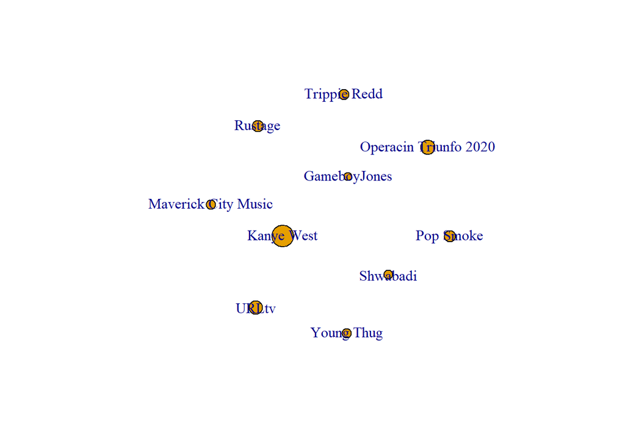

```r
graphe_top10 <- make_empty_graph(directed = FALSE)


artistes <- unique(top_10_artist_feat$artist)
graphe_top10 <- add_vertices(graphe_top10, length(artistes), name=artistes)

nb_total_feats <- rep(0, length(artistes))

for (i in 1:nrow(data)) {
  if (data$artist[i] %in% artistes) {
    nb_total_feats[data$artist[i] == artistes] <- nb_total_feats[data$artist[i] == artistes] + length(data$features[[i]])
  }
}

nb_feats <- matrix(0, nrow = length(artistes), ncol = length(artistes), dimnames = list(artistes, artistes))

for (i in 1:nrow(data)) {
  if (data$artist[i] %in% artistes) {
    for (j in data$features[[i]]) {
      for (k in j) {
        if (k %in% artistes) {
          nb_feats[data$artist[i], k] <- nb_feats[data$artist[i], k] + 1
          nb_feats[k, data$artist[i]] <- nb_feats[k, data$artist[i]] + 1
        }
      }
    }
  }
}

for (i in 1:length(artistes)) {
  for (j in 1:length(artistes)) {
    if (nb_feats[artistes[i], artistes[j]] > 0 && i < j) {
      graphe <- add_edges(graphe_top10, c(i, j), weight = nb_feats[artistes[i], artistes[j]] / 3)
    }
  }
}

plot(graphe_top10, vertex.size = nb_total_feats * 0.1, edge.width = E(graphe_top10)$weight, oriented = FALSE)
```

Création d’un dataframe qui nous sera utile pour notre analyse de réseau. On filtre la variable `language`par fr, et nous enlèverons les list de la variable `features`.

```r
reseau <- data
reseau <- reseau %>% filter(language == "fr")
reseau$features <- lapply(reseau$features, unlist)
```

On prend seulement les 1000 premieres lignes de notre dataset.

```r
reseau <- head(reseau, 1000)
```

Dans notre analyse de réseau, nous voulons montrer la propotion de feat. Où l’on notifie les noeuds comme des artistes, les arêtes comme des features. Plus le poids du noeud est volumineux, plus l’artiste est représenté dans la base de données.

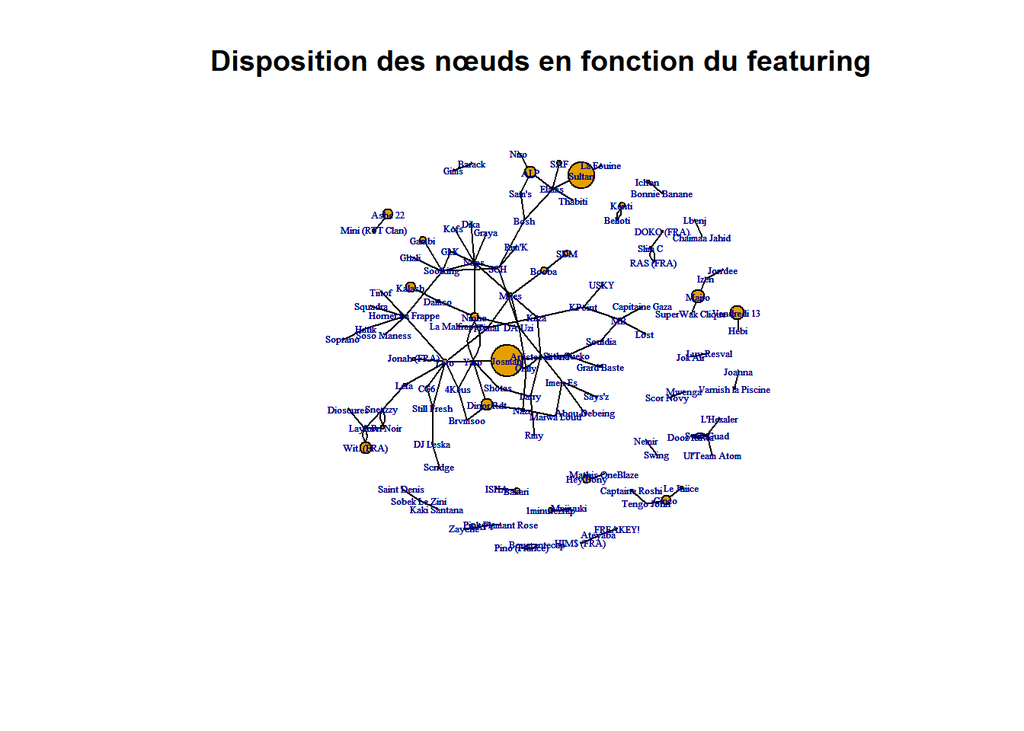

```r
graphe_feat <- make_empty_graph()

artistes <- unique(reseau$artist)
graphe_feat <- add_vertices(graphe_feat, length(artistes), name = artistes)

nb_total_feats <- rep(0, length(artistes))

for (i in 1:nrow(reseau)) {
  if (reseau$artist[i] %in% artistes) {
    nb_total_feats[reseau$artist[i] == artistes] <- nb_total_feats[reseau$artist[i] == artistes] + length(reseau$features[[i]])
  }
}

nb_feats <- matrix(0, nrow = length(artistes), ncol = length(artistes), dimnames = list(artistes, artistes))

for (i in 1:nrow(reseau)) {
  if (reseau$artist[i] %in% artistes) {
    for (j in reseau$features[[i]]) {
      for (k in j) {
        if (k %in% artistes) {
          nb_feats[reseau$artist[i], k] <- nb_feats[reseau$artist[i], k] + 1
          nb_feats[k, reseau$artist[i]] <- nb_feats[k, reseau$artist[i]] + 1
        }
      }
    }
  }
}

graphe_feat <- graph_from_adjacency_matrix(as.matrix(nb_feats), mode = "undirected")

sous_graphe <- induced_subgraph(graphe_feat, which(degree(graphe_feat) > 0))
layout <- layout_with_fr(sous_graphe)

plot(sous_graphe,
     layout = layout,
     vertex.size = nb_total_feats * 0.5,
      edge.color = "black",
     vertex.label.cex = 0.4,
     edge.width = E(sous_graphe)$weight,
      main = "Disposition des nœuds en fonction du featuring")
```

Dans ce graphe, on peut voir que se sont **Josman** et **Sultan** qui sont les plus représenté dans notre jeu de données. Nous pouvons voir également qu’ils se retrouvent entouré de plusieurs artistes, avec qui ils auraient fait des featuring, surtout pour Josman.

Dans ce graphe, nous voulions montrer la centralité de nos données, c’est à dire quel artiste à une influence sur les autres artistes.

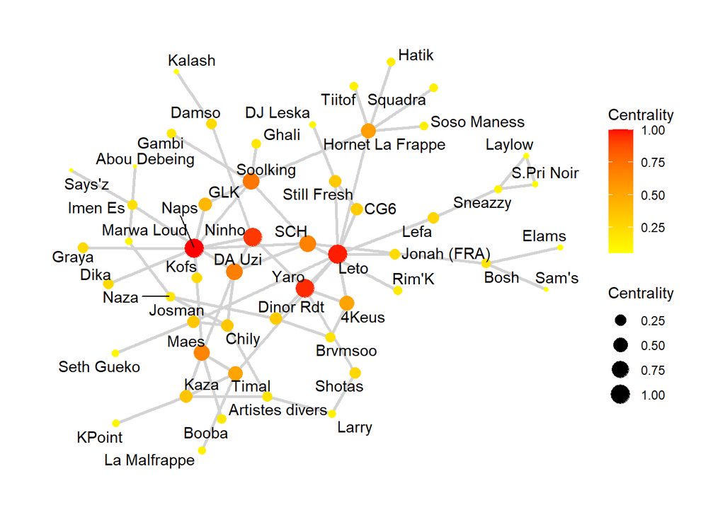

```r
graphe <- make_empty_graph()

artistes <- unique(reseau$artist)
graphe <- add_vertices(graphe, length(artistes), name = artistes)

nb_total_feats <- rep(0, length(artistes))

for (i in 1:nrow(reseau)) {
  if (reseau$artist[i] %in% artistes) {
    nb_total_feats[reseau$artist[i] == artistes] <- nb_total_feats[reseau$artist[i] == artistes] + length(reseau$features[[i]])
  }
}

nb_feats <- matrix(0, nrow = length(artistes), ncol = length(artistes), dimnames = list(artistes, artistes))

for (i in 1:nrow(reseau)) {
  if (reseau$artist[i] %in% artistes) {
    for (j in reseau$features[[i]]) {
      for (k in j) {
        if (k %in% artistes) {
          nb_feats[reseau$artist[i], k] <- nb_feats[reseau$artist[i], k] + 1
          nb_feats[k, reseau$artist[i]] <- nb_feats[k, reseau$artist[i]] + 1
        }
      }
    }
  }
}

graphe <- graph_from_adjacency_matrix(as.matrix(nb_feats), mode = "undirected")

sous_graphe <- induced_subgraph(graphe, which(degree(graphe) > 0))
layout <- layout_with_fr(sous_graphe)

clusters <- cluster_louvain(graphe)

phone_net <- as_tbl_graph(sous_graphe)

set.seed(123)
phone_net %>%
  activate(nodes) %>%
  mutate(centrality = centrality_authority()) %>%
  filter(centrality > 0.05) %>%
  ggraph(layout = "graphopt") +
  geom_edge_link(width = 1, colour = "lightgray") +
  geom_node_point(aes(size = centrality, colour = centrality)) +
  geom_node_text(aes(label = name), repel = TRUE) +
  scale_size_continuous(name = "Centrality") +
  scale_color_gradient(name = "Centrality", low = "yellow", high = "red") +
  theme_graph()
```

### 6.2 Modèle Siena

Malgré les différents tests effectués, nous n’avons pas reussi à faire le modèle SIENA sur nos données… Le modèle Siena permet d’expliquer l’apparition et la disparition des liens. Cela permet de voir l’évolution de reseau (dirigé ou non dirigé)/(bipartite dirigé ou non dirigé)

### 6.3 ERGM

Malgré les différents tests effectués, nous n’avons pas reussi à faire le modèle ERGM sur nos données… Le test ERGM est un test d’hypothese permettant de regarder la proportion de ces réseaux ayant la statistique à étudier supérieure ou égale a celle du réseau empirique. Cela permet de savoir si le reseau empirique est du au hasard ou non.

## 7. Conclusion

Pour conclure notre analyse de réseaux, nous souhaitons savoir qui sont les artistes influçants le plus les autres artistes en raison de leur forte présente dans les featurings.

Tout d’abord, nous avons récolté des données grâce au site référençant les paroles de musique Genius, téléchargé depuis Kaggle. Nous avons établi à l’aide de nos données un graphe reliant les artistes entre eux en fonction du nombre de featurings qu’ils ont fait. Suite à cela, nous avons calculé la centralité des artistes dans les featurings afin de savoir qui pourraient être le plus influant. Nous constatons que la présence d’artistes comme Leto, Naps, Ninho et Yaro influent sur les autres artistes. Nous notons qu’un artiste ayant le plus de featurings n’est pas forcément influent selon notre calcul de centralité.

Pour aller plus loin, nous pouvons faire notre analyse sur les artistes influencés pour vérifier les similarités selon les thématiques de leurs paroles par rapport à l’artiste influant.

## 8. Annexe

Comme expliqué auparavant, nous avons récupéré notre jeu de données sur Kaggle : https://www.kaggle.com/datasets/carlosgdcj/genius-song-lyrics-with-language-information